# Image classification of Brain Tumor Dataset

## Training over a sequential model

```python
model = Sequential()
model.add(Conv2D(32,3,padding="same", activation="relu", input_shape=(224,224,3)))
model.add(MaxPool2D())

model.add(Conv2D(32, 3, padding="same", activation="relu"))
model.add(MaxPool2D())

model.add(Conv2D(64, 3, padding="same", activation="relu"))
model.add(MaxPool2D())
model.add(Dropout(0.4))

model.add(Flatten())
model.add(Dense(128,activation="relu"))
model.add(Dense(4, activation="softmax"))

model.summary()

model.compile(loss="categorical_crossentropy",
              optimizer="adam",
              metrics=["accuracy"])
```

```
Model: "sequential_3"
_________________________________________________________________
 Layer (type)                Output Shape              Param #
=================================================================
 conv2d_26 (Conv2D)          (None, 224, 224, 32)      896

 max_pooling2d_20 (MaxPoolin  (None, 112, 112, 32)     0
 g2D)

 conv2d_27 (Conv2D)          (None, 112, 112, 32)      9248

 max_pooling2d_21 (MaxPoolin  (None, 56, 56, 32)       0
 g2D)

 conv2d_28 (Conv2D)          (None, 56, 56, 64)        18496

 max_pooling2d_22 (MaxPoolin  (None, 28, 28, 64)       0
 g2D)

 dropout (Dropout)           (None, 28, 28, 64)        0

 flatten_7 (Flatten)         (None, 50176)             0

 dense_9 (Dense)             (None, 128)               6422656

 dense_10 (Dense)            (None, 4)                 516

=================================================================
Total params: 6,451,812
Trainable params: 6,451,812
Non-trainable params: 0
_________________________________________________________________
```

```python
history = model.fit(x_train,y_train,epochs = 10 , validation_data = (x_val, y_val))
```

**Plot the results**

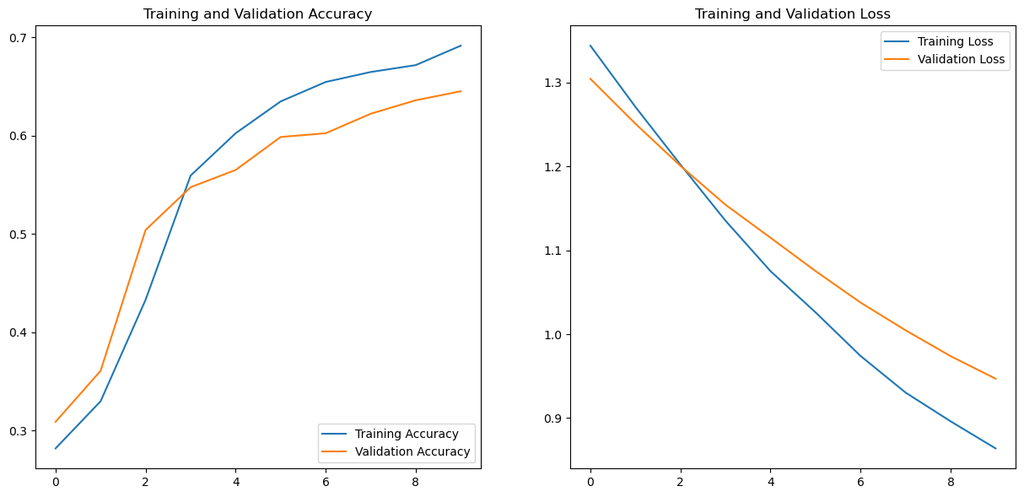

```python
acc = history.history['accuracy']
val_acc = history.history['val_accuracy']
loss = history.history['loss']
val_loss = history.history['val_loss']

epochs_range = range(10)

plt.figure(figsize=(15, 15))
plt.subplot(2, 2, 1)
plt.plot(epochs_range, acc, label='Training Accuracy')
plt.plot(epochs_range, val_acc, label='Validation Accuracy')
plt.legend(loc='lower right')
plt.title('Training and Validation Accuracy')

plt.subplot(2, 2, 2)
plt.plot(epochs_range, loss, label='Training Loss')
plt.plot(epochs_range, val_loss, label='Validation Loss')
plt.legend(loc='upper right')
plt.title('Training and Validation Loss')
plt.show()
```

## Training over vgg16 base model - pretrained model

```python
conv_base = keras.applications.vgg16.VGG16(
    weights="imagenet", #weights from imagenet, using [3]
    include_top=False,
    input_shape=(180, 180, 3))
```

```python
conv_base.summary()
```

```
Model: "vgg16"
_________________________________________________________________
 Layer (type)                Output Shape              Param #
=================================================================
 input_6 (InputLayer)        [(None, 180, 180, 3)]     0

 block1_conv1 (Conv2D)       (None, 180, 180, 64)      1792

 block1_conv2 (Conv2D)       (None, 180, 180, 64)      36928

 block1_pool (MaxPooling2D)  (None, 90, 90, 64)        0

 block2_conv1 (Conv2D)       (None, 90, 90, 128)       73856

 block2_conv2 (Conv2D)       (None, 90, 90, 128)       147584

 block2_pool (MaxPooling2D)  (None, 45, 45, 128)       0

 block3_conv1 (Conv2D)       (None, 45, 45, 256)       295168

 block3_conv2 (Conv2D)       (None, 45, 45, 256)       590080

 block3_conv3 (Conv2D)       (None, 45, 45, 256)       590080

 block3_pool (MaxPooling2D)  (None, 22, 22, 256)       0

 block4_conv1 (Conv2D)       (None, 22, 22, 512)       1180160

 block4_conv2 (Conv2D)       (None, 22, 22, 512)       2359808

 block4_conv3 (Conv2D)       (None, 22, 22, 512)       2359808

 block4_pool (MaxPooling2D)  (None, 11, 11, 512)       0

 block5_conv1 (Conv2D)       (None, 11, 11, 512)       2359808

 block5_conv2 (Conv2D)       (None, 11, 11, 512)       2359808

 block5_conv3 (Conv2D)       (None, 11, 11, 512)       2359808

 block5_pool (MaxPooling2D)  (None, 5, 5, 512)         0

=================================================================
Total params: 14,714,688
Trainable params: 14,714,688
Non-trainable params: 0
_________________________________________________________________
```

### Extracting features and labels

```python
train_dataset = image_dataset_from_directory(
    "Training",
    image_size=(180, 180),
    batch_size=32)
validation_dataset = image_dataset_from_directory(
    "Testing",
    image_size=(180, 180),
    batch_size=32)
```

```
Found 5712 files belonging to 4 classes.
Found 1311 files belonging to 4 classes.
```

```python
import numpy as np

def get_features_and_labels(dataset):
    all_features = []
    all_labels = []
    for images, labels in dataset:
        preprocessed_images = keras.applications.vgg16.preprocess_input(images)
        features = conv_base.predict(preprocessed_images)
        all_features.append(features)
        all_labels.append(labels)
    return np.concatenate(all_features), np.concatenate(all_labels)

train_features, train_labels =  get_features_and_labels(train)
val_features, val_labels =  get_features_and_labels(val)
```

```python
train_features.shape
```

```
(5712, 5, 5, 512)
```

### Training over a simple model

```python
y_train = to_categorical(train_labels, 4) #to make it compatible with the output layer(else gives errors)
y_val = to_categorical(val_labels, 4)

#training the model[3]
inputs = keras.Input(shape=(5, 5, 512))
x = layers.Flatten()(inputs)
x = layers.Dense(256)(x)
x = layers.Dropout(0.5)(x)
outputs = layers.Dense(4, activation="softmax")(x)


model = keras.Model(inputs, outputs)
model.compile(loss="categorical_crossentropy",
              optimizer="adam",
              metrics=["accuracy"])

callbacks = [
    keras.callbacks.ModelCheckpoint(
      filepath="feature_extraction.keras",
      save_best_only=True,
      monitor="val_loss")
]
history = model.fit(
    train_features, y_train,
    epochs=10,
    validation_data=(val_features, y_val),
    callbacks=callbacks)
```

**Plot the results**

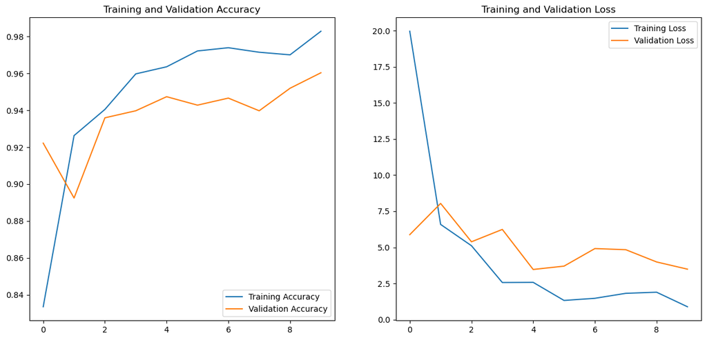

```python
import matplotlib.pyplot as plt
acc = history.history["accuracy"]
val_acc = history.history["val_accuracy"]
loss = history.history["loss"]
val_loss = history.history["val_loss"]
epochs = range(10)

plt.figure(figsize=(15, 15))
plt.subplot(2, 2, 1)
plt.plot(epochs_range, acc, label='Training Accuracy')
plt.plot(epochs_range, val_acc, label='Validation Accuracy')
plt.legend(loc='lower right')
plt.title('Training and Validation Accuracy')

plt.subplot(2, 2, 2)
plt.plot(epochs_range, loss, label='Training Loss')
plt.plot(epochs_range, val_loss, label='Validation Loss')
plt.legend(loc='upper right')
plt.title('Training and Validation Loss')
plt.show()
```

## Conclusion:

We trained the dataset from kaggle that consisted of images of brain tumor. We preprocessed the data and then applied two different models. One of the models resulted in a bit smooth curve in regards to validation loss and accuracy while the second model trained on a pretrained(vgg16) provided better validation accuracy, however the graph was fluctuating. Second model performed better in comparison.  
In future we aim to increase number of epochs, change parameter values and try to foresee model preformance over a higher epoch value.

## References

Work is inspired by:  
[1]https://www.analyticsvidhya.com/blog/2020/10/create-image-classification-model-python-keras/  
[2]https://www.kaggle.com/code/mushfirat/brain-tumor-classification-accuracy-96  
[3]chapter08_intro-to-dl-for-computer-vision (Chollet: Deep Learning with Python)

By: Murk Asad, Fairouz Sharif